# lm-twostands

MGM

2/3/2021

# Simulate the data!

Here I simulate the two tree stands with different DBHs. First, we simulate the means of the two stands (mu.dbh), and assign stands A or B. Then we give each observation a unique value using a random number from a normal distribution (rnorm) around the given mean value.

```r
set.seed(123)
mu.dbh <- rep(c(70, 100), each=25)           #deterministic part
Stand <- gl(n=2, k=25, labels = c("A", "B")) #make a two level factor
DBH <- rnorm(50, mu.dbh, 20)                 #stochastic part N(mean, sigma)
tree <- data.frame(DBH=DBH, Stand=Stand)
remove(DBH, mu.dbh, Stand)
head(tree)
```

|  | DBH | Stand |
| --- | --- | --- |
| 1 | 58.79049 | A |
| 2 | 65.39645 | A |
| 3 | 101.17417 | A |
| 4 | 71.41017 | A |
| 5 | 72.58575 | A |
| 6 | 104.30130 | A |

# Modeling process

Let’s do the modeling process!

## 1. State the question

In words: Is there a *significant* difference in DBH between stands?

- Response variable: DBH (continuous)
- Explanatory variable: Stand (two-level factor)

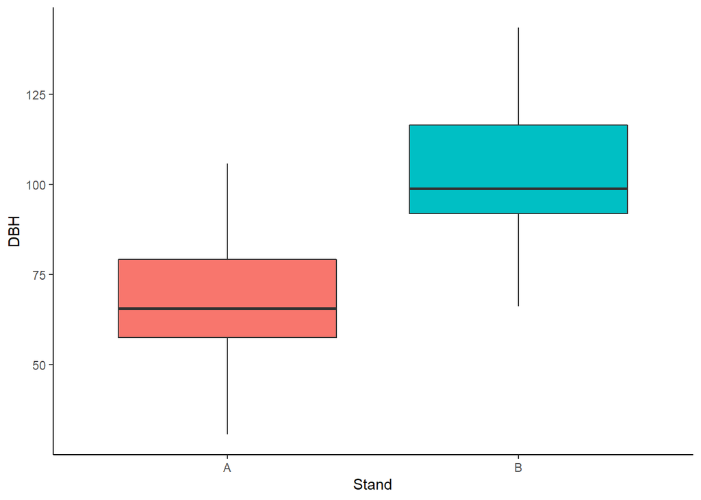

```r
ggplot(data = tree, aes(x = Stand, y = DBH, fill=Stand)) +
  geom_boxplot(show.legend = FALSE) +
  theme_classic()
```

## 2. Data exploration

What are the raw means for reference?

```r
tapply(tree$DBH, tree$Stand, mean)   #raw means
```

```
##         A         B
##  69.33339 102.04275
```

## 3. Describe the model

In words: is the difference between stand DBHs significantly different from 0?

H0: the difference between stands is no different from 0.

In mathematical form:
$$y_i = \beta_0 + \beta_1 X_i + e_i$$

- $y_i$ is DBH
- $X_i$ is stand

What are the model assumptions?

- Residuals are nomally distributed
- Constant variance (homogeneity)
- Observations are independent
- Predictors are measured without error (fixed X)

## 4. Fit the model

Algebraically:
$$y_i = \beta_0 + \beta_1 X_i + e_i$$

In R:

```r
m0 <- lm(DBH ~ Stand, data = tree)   #fit the model

# let's check out the coefficient of the model
coef(m0)
```

```
## (Intercept)      StandB
##    69.33339    32.70935
```

**Question: What does StandB stand for or represent?**

## 5. Evaluate the output

First, let’s check our assumptions using the plot() function! We will plot the first three graphs in that function, which are:

Residuals vs. fitted graph:

- Shows if residuals have a non-linear pattern. If there is a non-linear pattern it means the relationship between your response and explanatory variables is not represented by your model well.

Normal Q-Q plot:

- Shows if residuals are normally distributed. If the residuals follow the middle line, they are normally distributed.

Scale-location plot (a.k.a. Spread-location):

- Checks for equal variance or homoscedasticity. If residuals look randomly distributed, no problem, but if they follow a pattern, it is something to worry about.

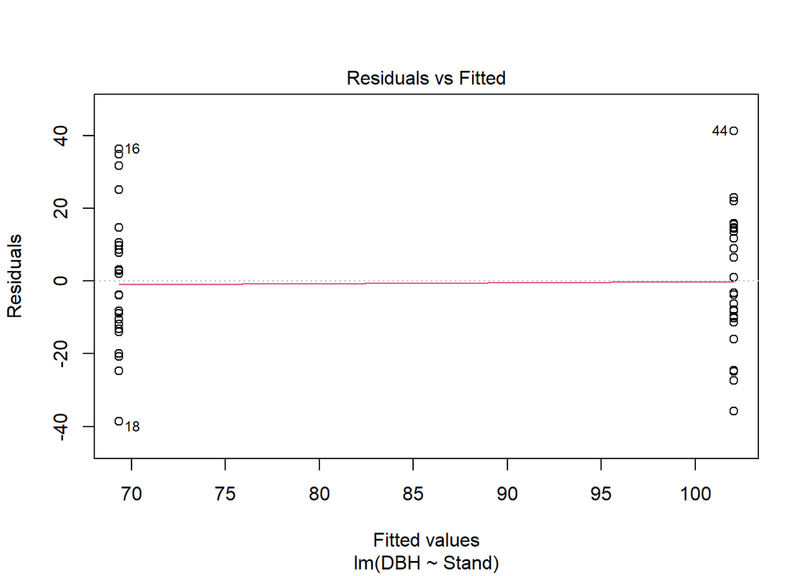

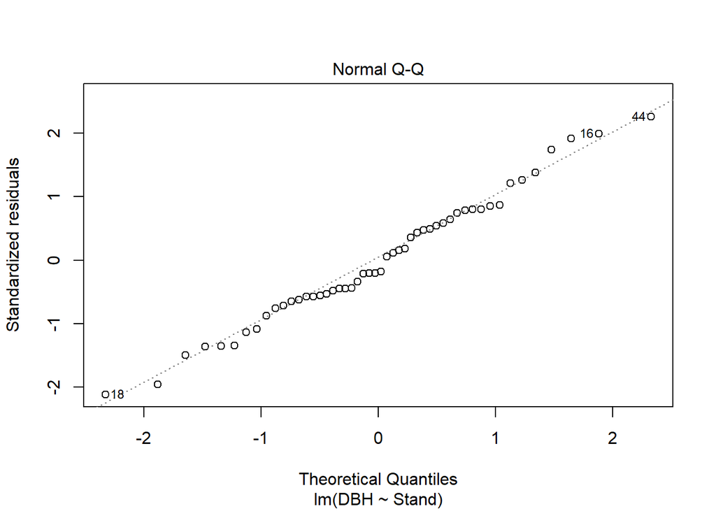

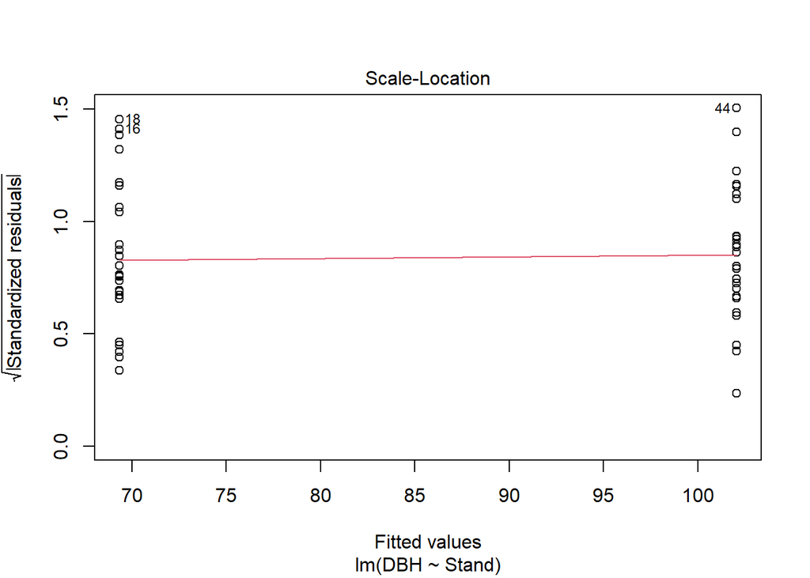

```r
plot(m0, c(1,2,3))
```

**Question: How do our results look?**

Note: we will save model selection for later when we have more models to test :).

## 6. Interpret the results

Well, what do we learn from our model? Use your notes from Tuesday to help interpret these results.

```r
summary(m0)
```

```
##
## Call:
## lm(formula = DBH ~ Stand, data = tree)
##
## Residuals:
##     Min      1Q  Median      3Q     Max
## -38.666 -11.168  -3.487  13.100  41.336
##
## Coefficients:
##             Estimate Std. Error t value Pr(>|t|)
## (Intercept)   69.333      3.732  18.580  < 2e-16 ***
## StandB        32.709      5.277   6.198 1.25e-07 ***
## ---
## Signif. codes:  0 '***' 0.001 '**' 0.01 '*' 0.05 '.' 0.1 ' ' 1
##
## Residual standard error: 18.66 on 48 degrees of freedom
## Multiple R-squared:  0.4446, Adjusted R-squared:  0.433
## F-statistic: 38.42 on 1 and 48 DF,  p-value: 1.248e-07
```

**Question: What does the estimate of the intercept, 69.33, mean in plain English?**

**Question: What does the estimate of StandB, 32.71, mean in plain English?**

**Question: What do you think the p (Pr(>|t|)) value for each estimate represents?**

**Question: What is the estimated mean of Stand B?**

**Question: For $y_i = \beta_0 + \beta_1 X_i + e_i$, what are our estimates of $\beta_0$, $\beta_1$, and $e_i$?**

### More interpretation

$R^2$ and $Adjusted R^2$ are often used to estimate how much *variation* in the data is explaned by the model. $R^2$ is used for one explanatory variable, and $Adjusted R^2$ corrects for multiple explanatory variables.

H0: the model is not significantly different than random noise at predicting y

```r
anova(m0)
```

|  | Df | Sum Sq | Mean Sq | F value | Pr(>F) |
| --- | --- | --- | --- | --- | --- |
| Stand | 1 | 13373.77 | 13373.7730 | 38.41646 | 1.248251e-07 |
| Residuals | 48 | 16710.05 | 348.1261 | NA | NA |

### Vizualizing the interpretation

Let’s plot the 95% confidence and prediction intervals

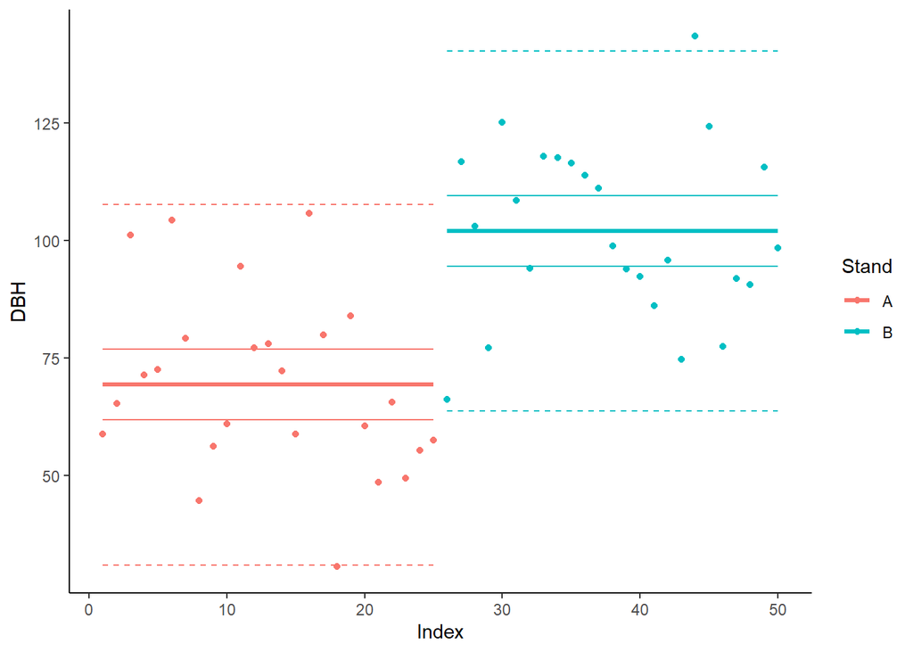

```r
new.data <- data.frame(Stand=c(rep("A",25), rep("B",25)))
CI.nd <- predict(m0, newdata = new.data, interval = "confidence")
colnames(CI.nd) <- c("CI.fit", "CI.lwr", "CI.upr")
PI.nd <- predict(m0, newdata = new.data, interval = "prediction")
colnames(PI.nd) <- c("PI.fit", "PI.lwr", "PI.upr")

new.df <- cbind(tree, CI.nd, PI.nd)
new.df$Index <- as.numeric(row.names(new.df))
remove(CI.nd, PI.nd, new.data)

ggplot(new.df, aes(x = Index, y = DBH, color = Stand)) +
  geom_point() +
  geom_line(aes(y=CI.fit), size=1.2) +
  geom_line(aes(y=CI.lwr)) +
  geom_line(aes(y=CI.upr)) +
  geom_line(aes(y=PI.lwr), linetype = "dashed") +
  geom_line(aes(y=PI.upr), linetype = "dashed") +
  theme_classic()
```

**Question: What are these confidence/prediction intervals showing you?**

*Bonus: try the Knit button at the top of this script… can you knit to a pdf? No worries if you can’t yet, but its pretty cool if you can :)*